# Stat 202, Project 1: NYC Housing

Jessica Li

jli6

There should be no collaborators

Due 3/9/18 at 11:59 pm

# Introduction

You hear about it all on the news, the exorbitant prices of the apartments and houses in New York. Some people get kicked out because they cannot afford the rent if if they had been living there for years in a closet sized room. Although NYC is one of the biggest hubs in the United States, I do not think the living situation can get more cramped. Sometimes I would wonder if I would ever be able to live there; and not just to live but to live nicely even if I was a millionare. How nice can an apartment get, and how much would a certain sum get me?

# Exploratory Data Analysis

## Data

```
## [1] 339
```

| Income | Age | MaintenanceDef | NYCMove |
| --- | --- | --- | --- |
| 8400 | 77 | 1 | 1981 |
| 17510 | 53 | 2 | 1986 |
| 19200 | 33 | 4 | 1992 |
| 42717 | 55 | 1 | 1969 |
| 5000 | 58 | 2 | 1989 |
| 30000 | 29 | 4 | 1994 |

In the data, we analyse a random sample of 339 families and 4 variables. We examine the relationship between the response variable, the income, and three explanatory variables, also known as the predictors of interest: Age, MaintenanceDef and NycMove. The income is total household income (in $). The age is the respondant’s age (in years); the MaintenanceDef is the number of maintenance deficiences between 2002 and 2005. And finally, the NYCMove is the year the respondent moved to New York City

## Univariate exploration

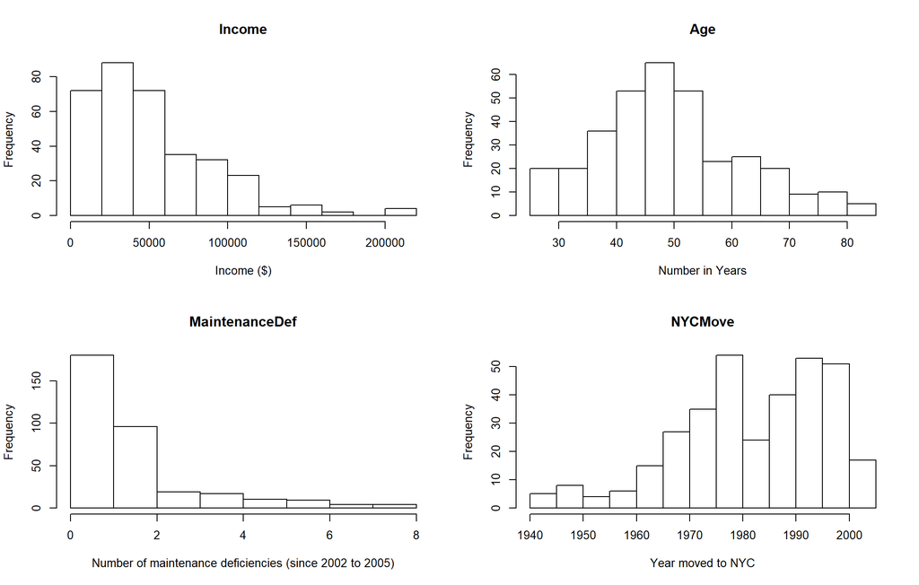

Continuous Variables

|  | Min | Q1 | Median | Mean | Q3 | Max | SD |
| --- | --- | --- | --- | --- | --- | --- | --- |
| Income | 1440 | 25500 | 41500 | 52493.719764 | 70000 | 209000 | 37801.650495 |
| Age | 26 | 42 | 49 | 50.120944 | 58 | 85 | 12.559920 |
| MaintenanceDef | 0 | 1 | 1 | 1.852507 | 2 | 8 | 1.573284 |
| NYCMove | 1942 | 1973 | 1984 | 1982.203540 | 1994 | 2004 | 13.835782 |

## Bivariate exploration

### Predictor variables

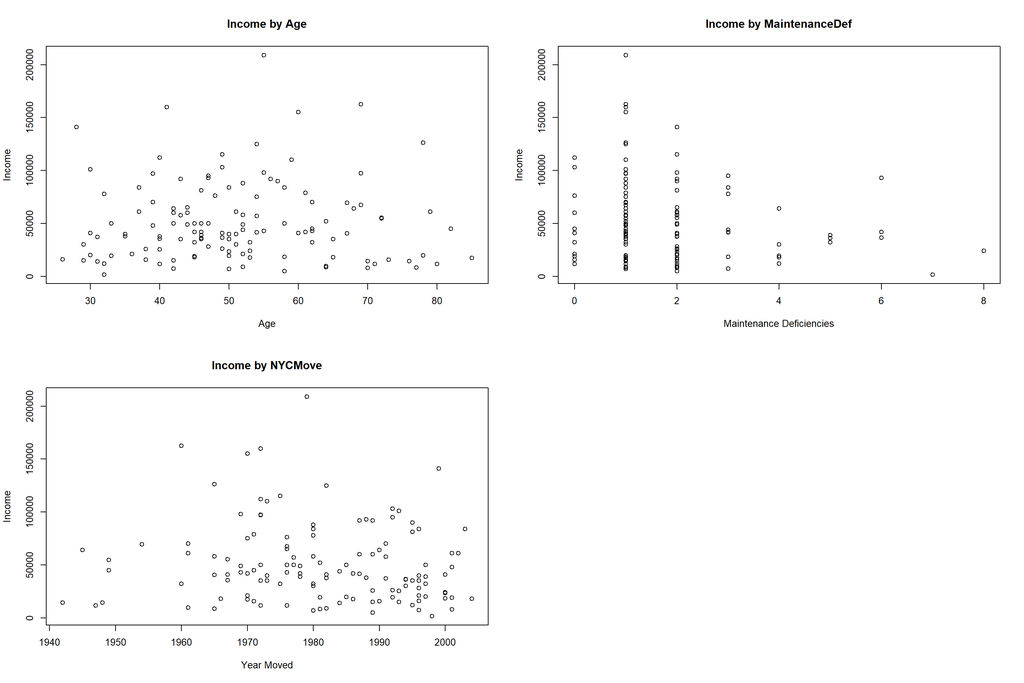

# Modeling

We are beginning to make a linear regression model to predict income. We do this by first looking at the histograms and the scatterplots.

What we can first see is that Income does not look normal, so what we must first do is transform it is normal.

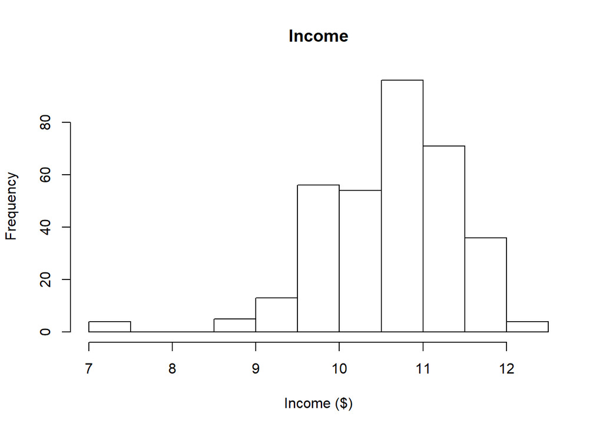

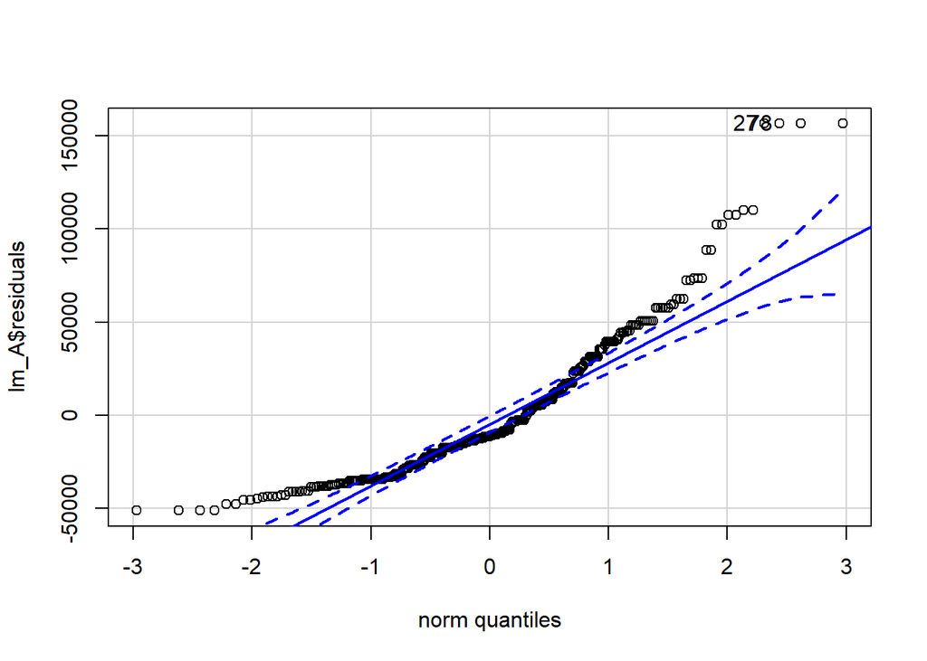

```
## [1] 27 78
```

Now we see that it is still not perfectly normal, but that can be excused with the fact that we have a very large population sample of n=339 households.

We can now prove Age’s diagnostics:

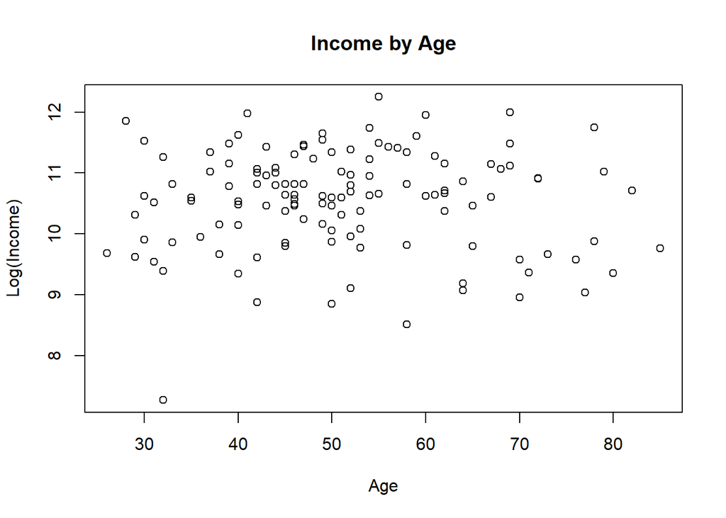

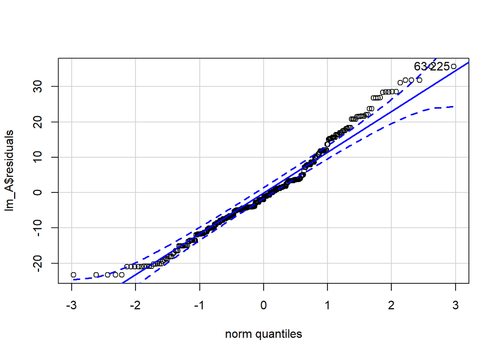

```
## [1]  63 225
```

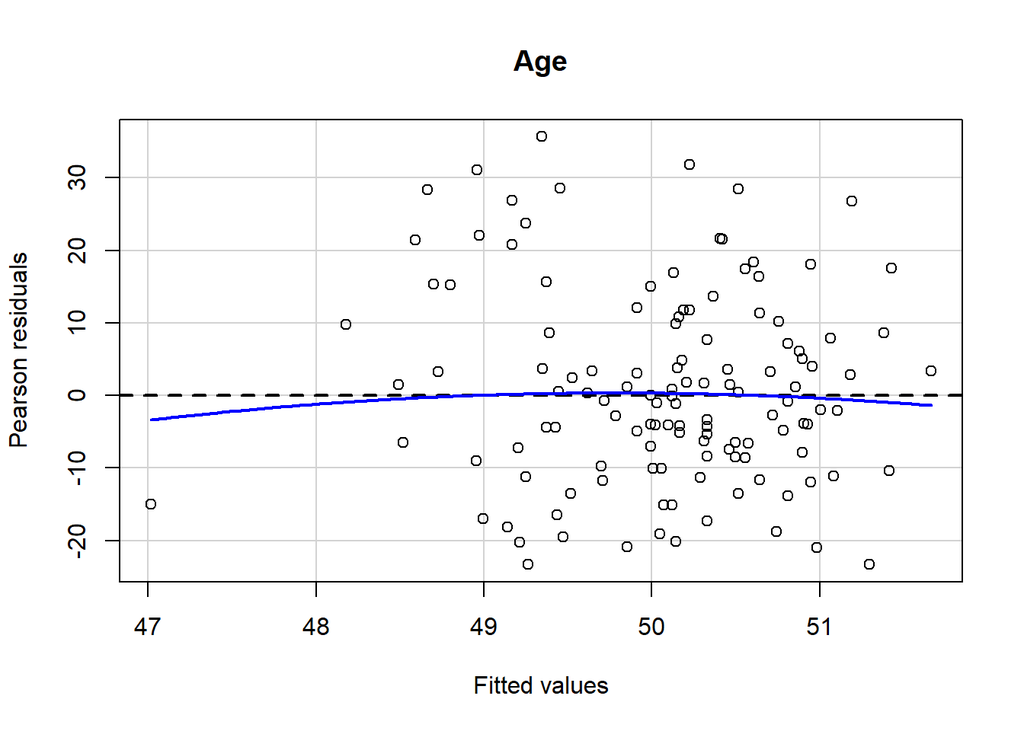

Now we prove MaintenanceDef’s diagnostics:

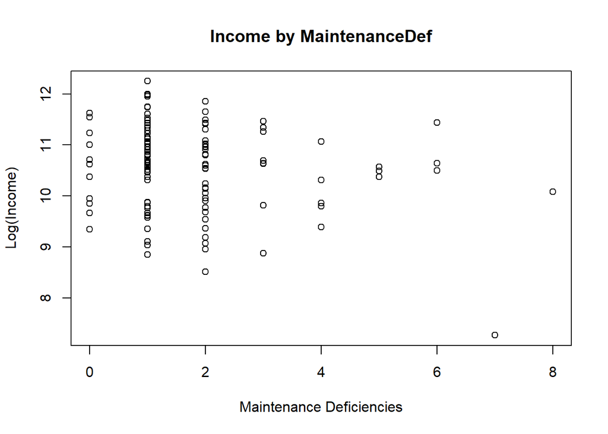

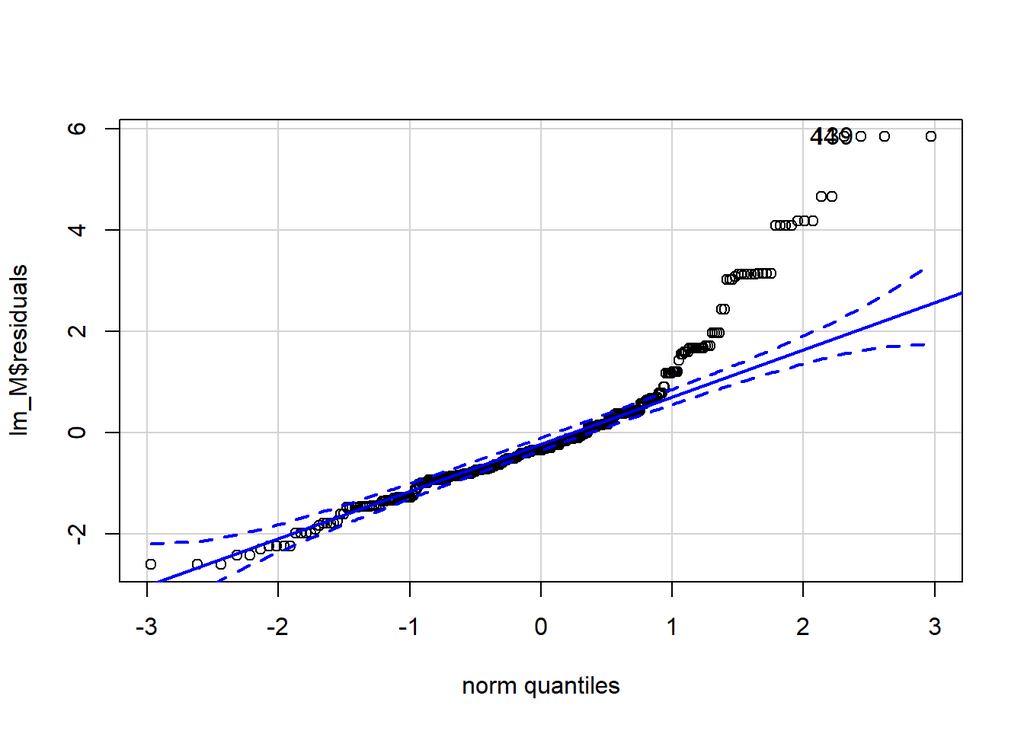

```
## [1]  44 139
```

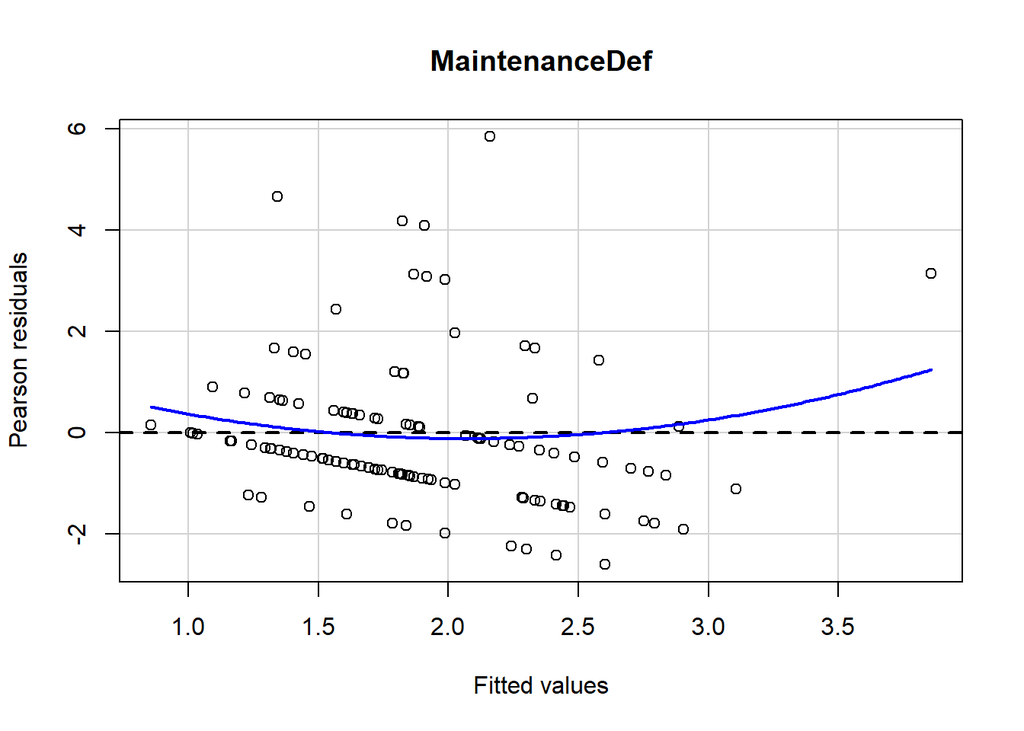

Now we prove NYCMove’s diagnostics:

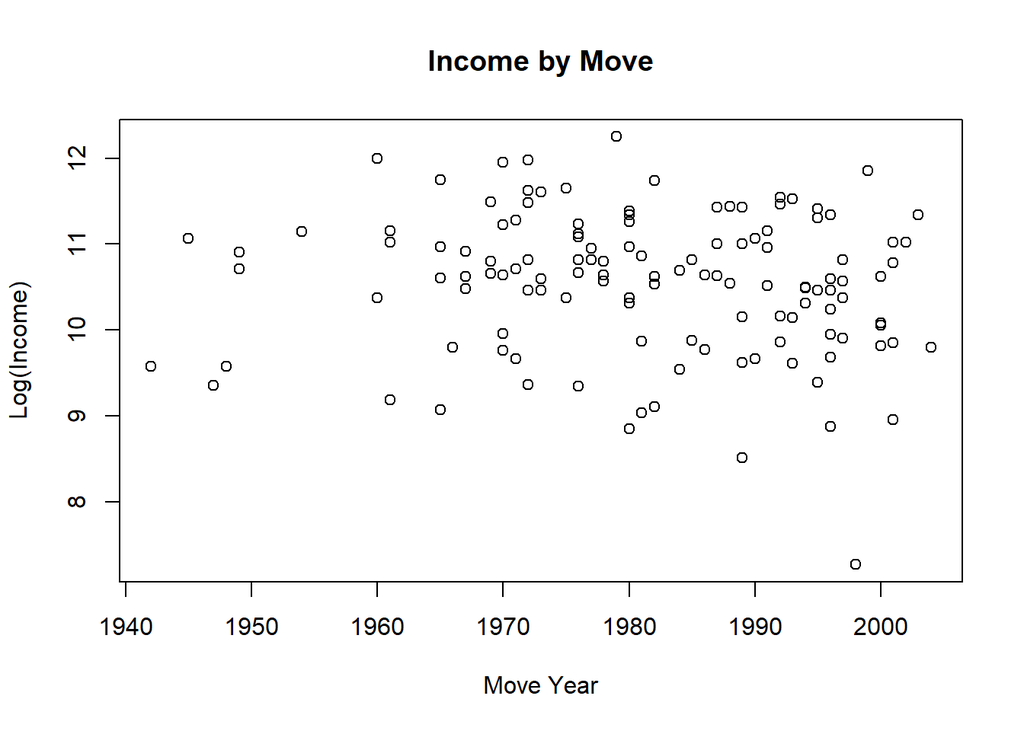

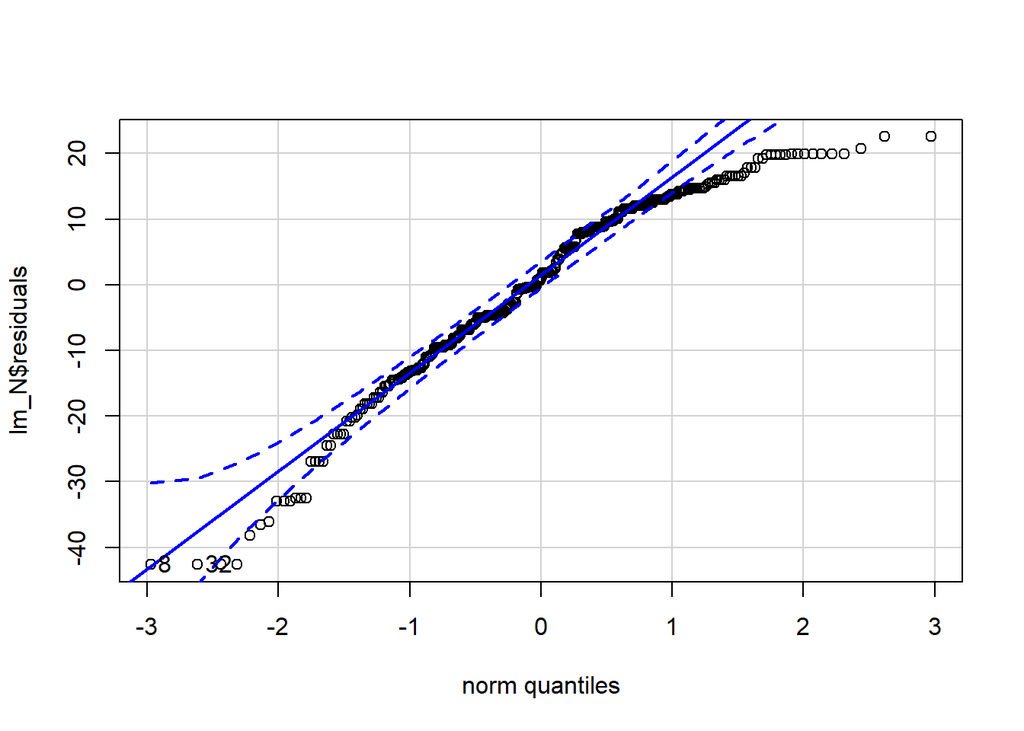

```
## [1]  8 32
```

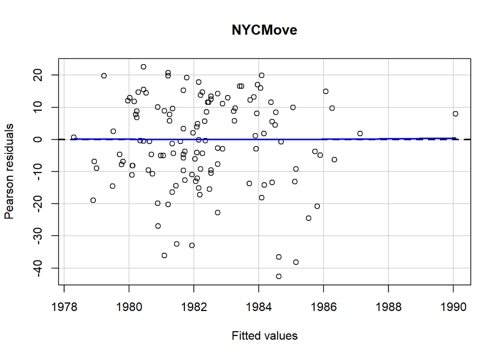

Additionally, there is always the idea of multicollinearity with multiple variables and to get rid of variables that may induce an incorrect result we checked if there was strong linear relationships with other variables.

|  | Estimate | Std. Error | t value | Pr(>\|t\|) |
| --- | --- | --- | --- | --- |
| **(Intercept)** | 13.56 | 8.62 | 1.573 | 0.1166 |
| **MaintenanceDef** | -0.1566 | 0.0296 | -5.29 | 2.216e-07 |
| **NYCMove** | -0.001308 | 0.004289 | -0.305 | 0.7606 |
| **Age** | -0.001595 | 0.004381 | -0.3641 | 0.716 |

Fitting linear model: log_income ~ MaintenanceDef + NYCMove + Age

| Observations | Residual Std. Error | $R^2$ | Adjusted $R^2$ |
| --- | --- | --- | --- |
| 339 | 0.7707 | 0.096 | 0.0879 |

| MaintenanceDef | NYCMove | Age |
| --- | --- | --- |
| 1.234 | 2.004 | 1.723 |

None of the VIF’s are >= 2.5;therefore, it should be concluded that there is no multicollinearity

|  | Estimate | Std. Error | t value | Pr(>\|t\|) |
| --- | --- | --- | --- | --- |
| **(Intercept)** | 11.56 | 6.624 | 1.745 | 0.08197 |
| **MaintenanceDef** | -0.1573 | 0.02949 | -5.335 | 1.761e-07 |
| **NYCMove** | -0.0003364 | 0.003353 | -0.1003 | 0.9201 |

Fitting linear model: log_income ~ MaintenanceDef + NYCMove

| Observations | Residual Std. Error | $R^2$ | Adjusted $R^2$ |
| --- | --- | --- | --- |
| 339 | 0.7697 | 0.09564 | 0.09026 |

| MaintenanceDef | NYCMove |
| --- | --- |
| 1.228 | 1.228 |

The equation of the final model is:

We see negative Beta value with Maintenance deficiencies which confirms out EDA results. We also see a negative Beta with NYCMove as well which is interesting, albeit not so significant.

- $\hat{\beta_1}$ = -0.1573. This means, controlling for the other variable in the model, we predict that for an increase of a maintenance deficiency there is a decrease of -0.1573 of log(dollars) in income.
- $\hat{\beta_2}$ = -0.0003364. This means, controlling for the other variable in the model, we predict that for an increase of a year there is a decrease of 0.0003364 of log(dollars) in income.

# Prediction

I am interested in predicting the income for a household with three maintenance deficiencies and whose respondent’s age is 53 and who moved to NYC in 1987. Im interested as from the results we concluded that with more maintenance deficiencies there is a lower income.

| Data to predict | Prediction Point Estimate | 95% confidence interval | 95% prediction interval |
| --- | --- | --- | --- |
| log(money)~Age=53, Maintenance Deficiency=3,NYCMove = 1987 | 10.41493 | (10.31306 , 10.5168) | (8.897545, 11.93231) |
|  | $33353.9004658 | (30123.473581, 36930.756783) | (7313.99562104,152102.512979) |
|  | converted ^ | converted ^ | converted ^ |

# Discussion

In the analysis of the results of this study, I have leanred that log(income) of a household is related to Maintenane Deficiencies. There were no strong multicollinearity between any variables studied. In the predictors of age and the year that a person moved to NYC there was no significance.

I was honestly surprised to find out that age was no a huge indicator of income until I realized that when people grow older they retire and have less money. The older people also cannot make that money for themselves even if they wanted to probably because of health. I was not surprised that the year was not a terribly big indicator because NYC has been a place that has been the heart of the US and a very expensive place to live for a very long time. It was probably only considered cheaper in a time period before the first year studied, 1942.

I think it is very interesting to study these situations of classes and what benefits or problems there are because of it. It makes people less ignorant and definitely can be eye-opening. I would like to know if the size of the room is an indicator of income as well. That would be my biggest additional question for this study.